```python
import numpy as np
import matplotlib.pyplot as plt
```

# 1. Derive the Michaelis Menten reaction equation

We have a reaction given by

$$ E + S \leftrightarrow ES \rightarrow E+P $$

with rates $k_{1}, k_{2}$ and $k_3$.

We want to prove that $ \dfrac{dP}{dt} = k_3 E_t \dfrac{S}{S+K_M}$ with $K_M = (k_2 + k_3)/k_1$.

We can get the equations for each part of the reaction:

We actually only need equations 3 and 4. Also, we write $[E] = [E_T] - [ES]$, where $[E]$ is the free enzyme concentration and $[E_T]$ the total enzyme concentration. We make the steady state approximation, where we assume that $d[ES]/dt = 0$, so $k_1 [E][S] = (k_2+k_3)[ES]$. Then, we make the substitution $[E] = [E_T]-[ES]$ into this equation:

$$ k_1 ([E_T]-[ES]) [S] = (k_2+k_3)[ES] \\ \Rightarrow [ES] = \dfrac{[E_T][S]}{K_M + [S]} $$

## 2.

Test by numerical integration of ODE's that the:

1. integral negative feedback
2. incoherent feedforward

can perform adaptation.

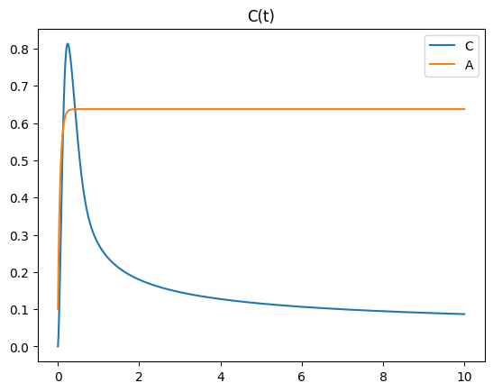

```python
#Integral negative feedback

from scipy.integrate import solve_ivp
import numpy as np
import matplotlib.pyplot as plt
#parameters
IkIA = 20
KIA = 0.5

FAkFAA = 15
KFAA = 0.5

kCB = 20
KCB = 1e-4

FBkFBB = 1
KFBB = 1e-4

kAC = 20
KAC = 0.5

kBC = 2.5
KBC = 0.5

#initial conditions
ic = [0.1,0.1,0]
t0 = 0

tmax = 10

def derivs(t,var):
    dvar = np.zeros(3)
    A,B,C = var
    dvar[0] = IkIA * ((1-A)/(1-A+KIA)) - FAkFAA*A/(A+KFAA)
    dvar[1] = C*kCB * ((1-B)/(1-B+KCB)) - FBkFBB*B/(B+KFBB)
    dvar[2] = A*kAC * ((1-C)/(1-C+KAC)) - B*kBC*C/(C+KBC)
    return dvar



sol = solve_ivp(derivs,[t0, tmax], ic,max_step = tmax/1000)
plt.plot(sol.t,sol.y[2],label="C")
plt.plot(sol.t,sol.y[0],label="A")
# plt.plot(sol.t,sol.y[1],label="B")
# plt.ylim([0,1])

plt.legend()
plt.title("C(t)")
```

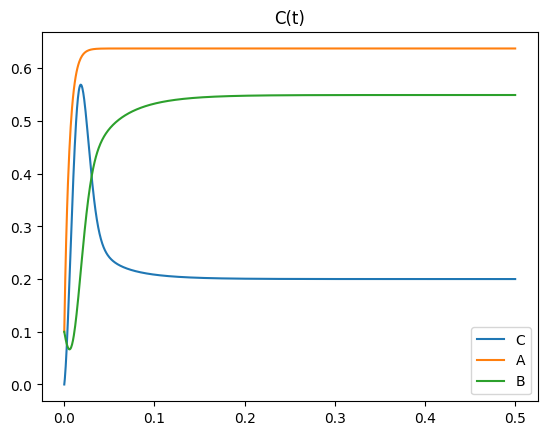

```python
#Integral negative feedback

from scipy.integrate import solve_ivp
import numpy as np
import matplotlib.pyplot as plt
#parameters
IkIA = 200
KIA = 0.5

FAkFAA = 150
KFAA = 0.5

kCB = 50
KCB = 1e-4

FBkFBB = 10
KFBB = 1e-4

kAC = 200
KAC = 0.5

kBC = 500
KBC = 0.5

#initial conditions
ic = [0.1,0.1,0]
t0 = 0

tmax = 0.5

def derivs(t,var):
    dvar = np.zeros(3)
    A,B,C = var
    dvar[0] = IkIA * ((1-A)/(1-A+KIA)) - FAkFAA*A/(A+KFAA)
    dvar[1] = C*kCB * ((1-B)/(1-B+KCB)) - FBkFBB*B/(B+KFBB)
    dvar[2] = A*kAC * ((1-C)/(1-C+KAC)) - B*kBC*C/(C+KBC)
    return dvar



sol = solve_ivp(derivs,[t0, tmax], ic,max_step = tmax/1000)
plt.plot(sol.t,sol.y[2],label="C")
plt.plot(sol.t,sol.y[0],label="A")
plt.plot(sol.t,sol.y[1],label="B")
# plt.ylim([0,1])

plt.legend()
plt.title("C(t)")
```

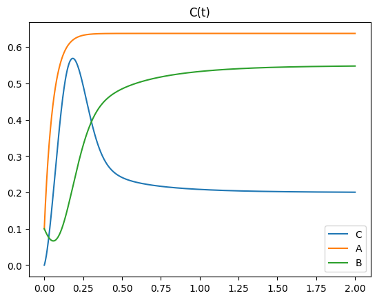

```python
#Integral negative feedback

from scipy.integrate import solve_ivp
import numpy as np
import matplotlib.pyplot as plt
#parameters
IkIA = 20
KIA = 0.5

FAkFAA = 15
KFAA = 0.5

kCB = 5
KCB = 1e-4

FBkFBB = 1
KFBB = 1e-4

kAC = 20
KAC = 0.5

kBC = 50
KBC = 0.5

#initial conditions
ic = [0.1,0.1,0]
t0 = 0

tmax = 2

def derivs(t,var):
    dvar = np.zeros(3)
    A,B,C = var
    dvar[0] = IkIA * ((1-A)/(1-A+KIA)) - FAkFAA*A/(A+KFAA)
    dvar[1] = C*kCB * ((1-B)/(1-B+KCB)) - FBkFBB*B/(B+KFBB)
    dvar[2] = A*kAC * ((1-C)/(1-C+KAC)) - B*kBC*C/(C+KBC)
    return dvar



sol = solve_ivp(derivs,[t0, tmax], ic,max_step = tmax/1000)
plt.plot(sol.t,sol.y[2],label="C")
plt.plot(sol.t,sol.y[0],label="A")
plt.plot(sol.t,sol.y[1],label="B")
# plt.ylim([0,1])

plt.legend()
plt.title("C(t)")
```

```python
#Integral negative feedback

from scipy.integrate import solve_ivp
import numpy as np
import matplotlib.pyplot as plt
#parameters
IkIA = 200
KIA = 0.5

FAkFAA = 150
KFAA = 0.5

kCB = 20
KCB = 1e-4

FBkFBB = 10
KFBB = 1e-4

kAC = 200
KAC = 0.5

kBC = 250
KBC = 0.5

#initial conditions
ic = [0.1,0.1,0]
t0 = 0

tmax = 1

def derivs(t,var):
    dvar = np.zeros(3)
    A,B,C = var
    dvar[0] = IkIA * ((1-A)/(1-A+KIA)) - FAkFAA*A/(A+KFAA)
    dvar[1] = C*kCB * ((1-B)/(1-B+KCB)) - FBkFBB*B/(B+KFBB)
    dvar[2] = A*kAC * ((1-C)/(1-C+KAC)) - B*kBC*C/(C+KBC)
    return dvar



sol = solve_ivp(derivs,[t0, tmax], ic,max_step = tmax/1000)
plt.plot(sol.t,sol.y[2],label="C")
plt.plot(sol.t,sol.y[0],label="A")
plt.plot(sol.t,sol.y[1],label="B")
# plt.ylim([0,1])

plt.legend()
plt.title("C(t)")
```

[output not shown]

[figure not shown]

```python
plt.plot(sol.t,sol.y[0])
plt.title("B(t)")
```

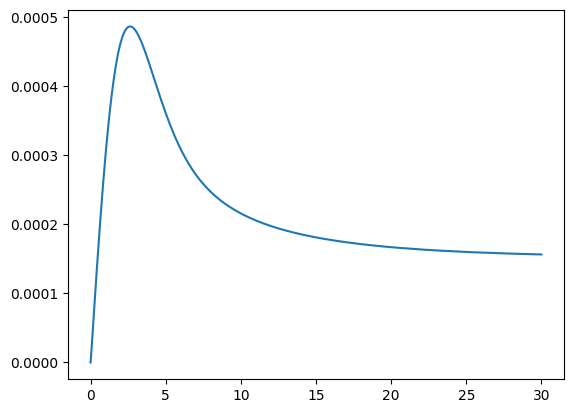

```python
# Incoherent feedforward.

from scipy.integrate import solve_ivp
import numpy as np
import matplotlib.pyplot as plt
#parameters
I = 1
kIA = 1
KIA = 1

FA = 100
kFAA = 0.5
KFAA = 0.5

kAB = 10
KAB = 0.5
FB = 0.1
kFBB = 1
KFBB = 0.5
kAC = .1
KAC = .5
kBC = 10
KBC = 1

#initial conditions
ic = [0,0,0]
t0 = 0

tmax = 30

def derivs(t,var):
    dvar = np.zeros(3)
    A,B,C = var
    dvar[0] = I*kIA * ((1-A)/(1-A+KIA)) - FA*kFAA*A/(A+KFAA)
    dvar[1] = A*kAB * ((1-B)/(1-B+KAB)) - FB*kFBB*B/(B+KFBB)
    dvar[2] = A*kAC * ((1-C)/(1-C+KAC)) - B*kBC*C/(C+KBC)
    return dvar



sol = solve_ivp(derivs,[t0, tmax], ic,max_step = tmax/100)
plt.plot(sol.t,sol.y[2])
```

# 3.

With the model formulated in slide $8$ show that:

1. $\alpha_{AA} = \dfrac{\partial f_A}{\partial A} <0$ if there is no positive feedback on $A$.
2. $\beta_{BA} = \dfrac{\partial f_A}{\partial B}$ has the sign of the regulation. That is $>0$ if $B -> A$ link is positive and $<0$ if the link is negative.

a) If there is no positive feedback on A, the equation would look like

$$ f_A = k_{IA} I \dfrac{1-A}{1-A+K_{IA}} - \sum_i k'_{Y_i A} Y_i \dfrac{A}{A+K'_{Y_iA}}$$

Calculating the derivative we find:

$$ \dfrac{\partial f_A}{\partial A} = \dfrac{(1-A)I k_{IA}}{(1-A+K_{IA})^2} - \dfrac{I k_{IA}}{1-A+K_{IA}} + \sum_i k_{Y_iA} Y_i \left( \dfrac{A}{(A+K_{Y_iA})^2} - \dfrac{1}{A+K_{Y_iA}} \right)$$

Summing up the fractions, this is simplified to:

$$ - \dfrac{I k_{IA} K_{IA}}{(1-A + K_{IA})^2} -\sum_i \dfrac{k_{Y_iA} K_{Y_iA} Y_i }{(A+K_{Y_iA})^2} $$

We see that every quantity here is negative, so the sum is negative.

b) We start considering the complete expression for $f_A$, which is

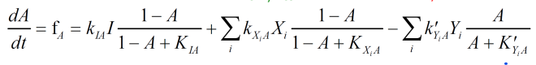

Then, if $B \rightarrow A$ is a positive link, $B$ will appear as one of the $X_i$ terms, so that the derivative will be equal to:

$$\dfrac{\partial f_A}{\partial B} = k_{BA} \dfrac{1-A}{1-A+K_{BA}},$$

which is positive.

On the other hand, if the link $B \rightarrow A$ is negative, then $B$ will appear as one of the $Y_i$, so differentiating with respect to $B$ we get:

$$\dfrac{\partial f_A}{\partial B} = -k'_{BA} \dfrac{A}{A+K'_{BA}},$$

which is negative.

# 4.

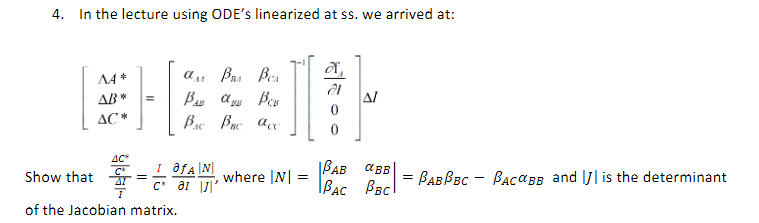

We can see that if $J^{-1}$ is the inverse matrix, then $\Delta C^* = J^{-1}_{31} \dfrac{\partial f_A}{\partial I} \Delta I$. Then, we use the formula for inverse matrix using minors and we get the result

# Fold change detection and cancer

# 1.

Implement the 3 fold-change detecting networks form Shoval et al 2010 (uploaded to absalon)

a) and investigate under which conditions the output is no longer fold-change detector

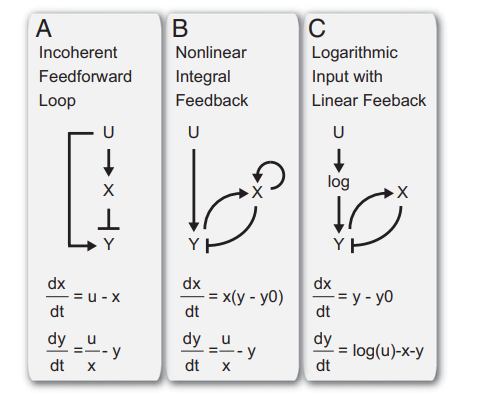

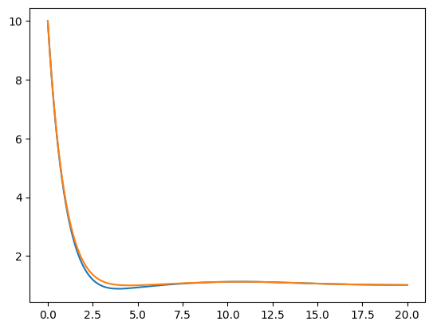

```python
#Integral negative feedback

from scipy.integrate import solve_ivp
import numpy as np
import matplotlib.pyplot as plt


ic = [10,10]
t0 = 0

tmax = 20
u = lambda t: 1*(np.tanh(5*(t-tmax/2)/tmax)+2)
u2 = lambda t: 2*(np.tanh(5*(t-tmax/2)/tmax)+2)

def derivs(t,var):
    dvar = np.zeros(2)
    x,y = var
    dvar[0] = u(t)-x
    dvar[1] = u(t)/x-y
    return dvar

def derivs2(t,var):
    dvar = np.zeros(2)
    x,y = var
    dvar[0] = u2(t)-x
    dvar[1] = u2(t)/x-y
    return dvar



sol = solve_ivp(derivs,[t0, tmax], ic,max_step = tmax/1000)
sol2 = solve_ivp(derivs2,[t0, tmax], ic,max_step = tmax/1000)

plt.plot(sol.t,sol.y[1])
plt.plot(sol2.t,sol2.y[1])
```

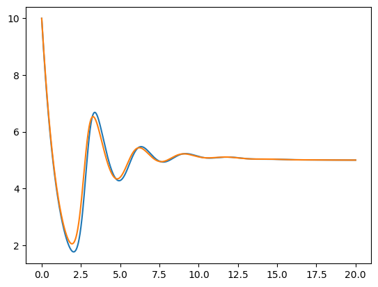

```python
#Integral negative feedback

from scipy.integrate import solve_ivp
import numpy as np
import matplotlib.pyplot as plt


ic = [10,10]
t0 = 0
y0=5
tmax = 20
u = lambda t: 5*(np.tanh(5*(t-tmax/2)/tmax)+2)
u2 = lambda t: 10*(np.tanh(5*(t-tmax/2)/tmax)+2)

def derivs(t,var):
    dvar = np.zeros(2)
    x,y = var
    dvar[0] = x*(y-y0)
    dvar[1] = u(t)/x-y
    return dvar

def derivs2(t,var):
    dvar = np.zeros(2)
    x,y = var
    dvar[0] = x*(y-y0)
    dvar[1] = u2(t)/x-y
    return dvar



sol = solve_ivp(derivs,[t0, tmax], ic,max_step = tmax/1000)
sol2 = solve_ivp(derivs2,[t0, tmax], ic,max_step = tmax/1000)

plt.plot(sol.t,sol.y[1])
plt.plot(sol2.t,sol2.y[1])
```

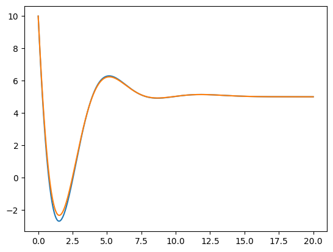

```python
#Integral negative feedback

from scipy.integrate import solve_ivp
import numpy as np
import matplotlib.pyplot as plt


ic = [10,10]
t0 = 0
y0=5
tmax = 20
u = lambda t: 5*(np.tanh(5*(t-tmax/2)/tmax)+2)
u2 = lambda t: 10*(np.tanh(5*(t-tmax/2)/tmax)+2)

def derivs(t,var):
    dvar = np.zeros(2)
    x,y = var
    dvar[0] = y-y0
    dvar[1] = np.log(u(t))-x-y
    return dvar

def derivs2(t,var):
    dvar = np.zeros(2)
    x,y = var
    dvar[0] = y-y0
    dvar[1] = np.log(u2(t))-x-y
    return dvar



sol = solve_ivp(derivs,[t0, tmax], ic,max_step = tmax/1000)
sol2 = solve_ivp(derivs2,[t0, tmax], ic,max_step = tmax/1000)

plt.plot(sol.t,sol.y[1])
plt.plot(sol2.t,sol2.y[1])
```